# BurcuHW1

Burcu Oral

18 10 2019

The data was taken as the initial data posted on the site. It may not produce realiable results with new data due to coding.

## TASK 1

## Plots

Plots for Poisson distribution and histograms will be :

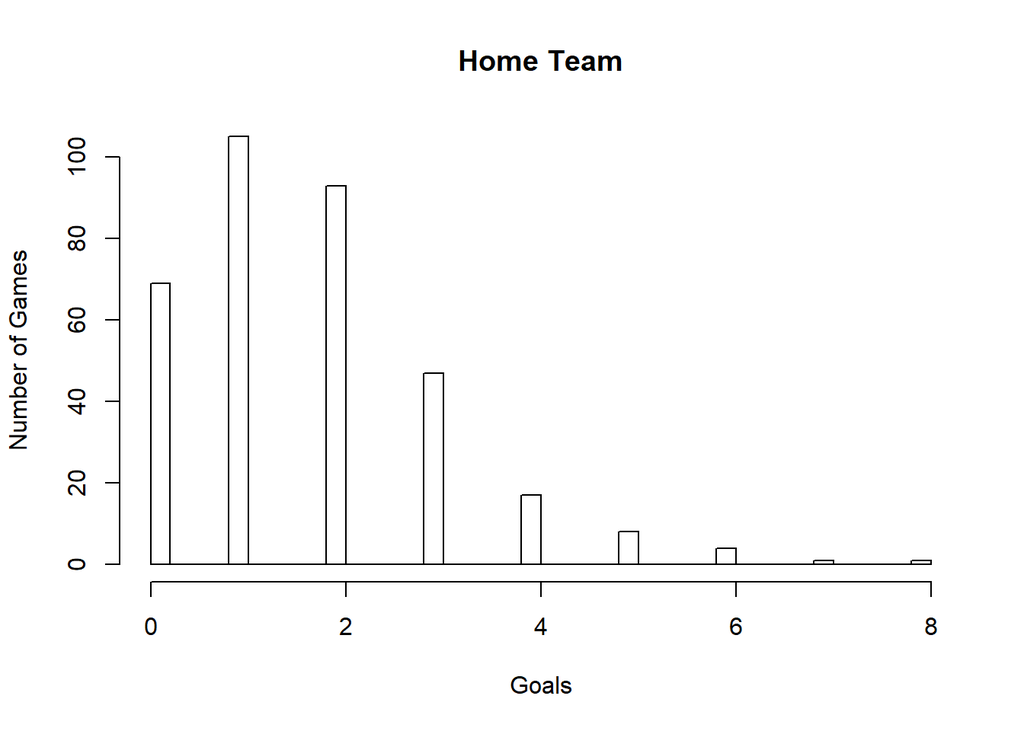

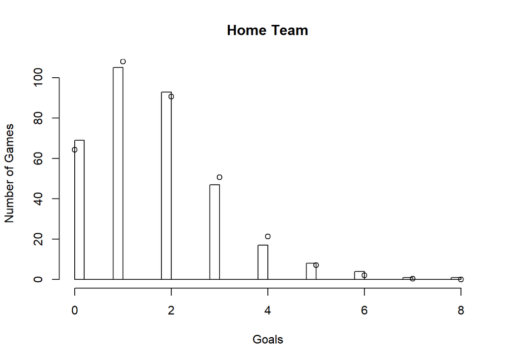

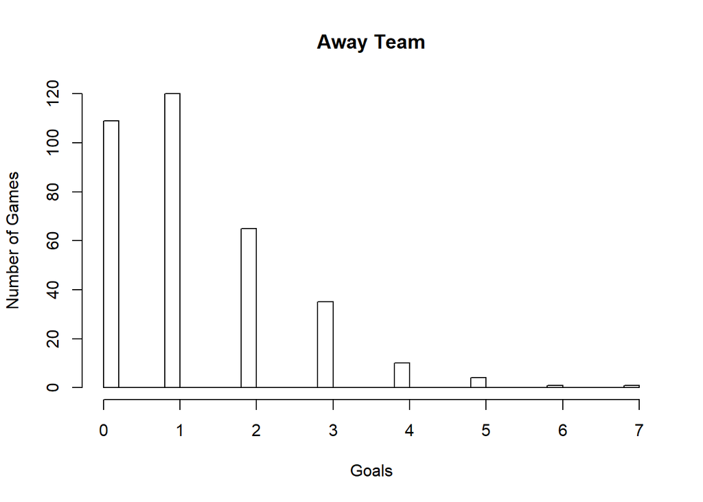

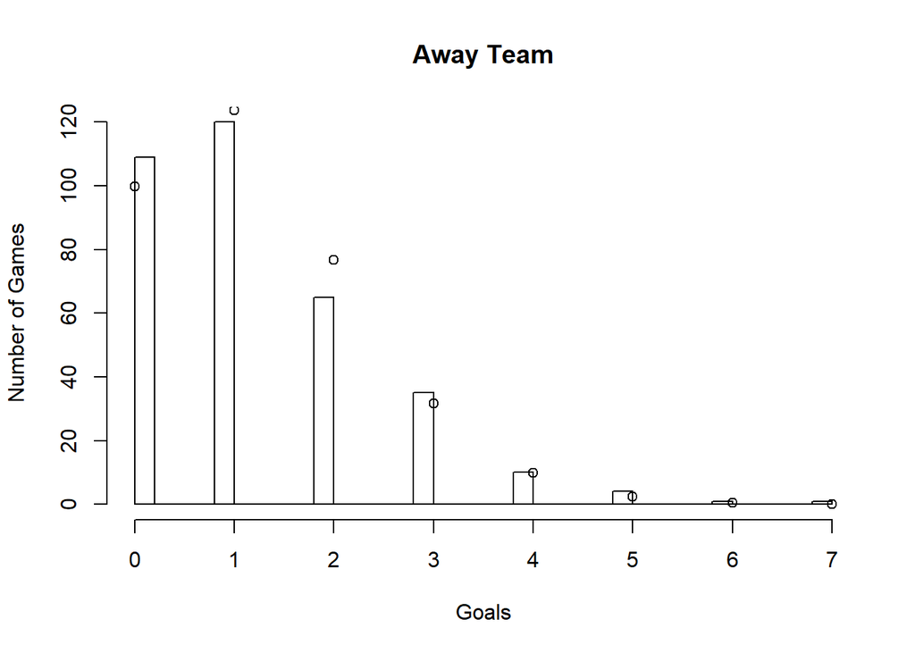

Since the histogram data trend matches with poisson distribution, it is consistent with Poisson distribution.

## TASK 2

For first bookmaker(Betclic) the results are:

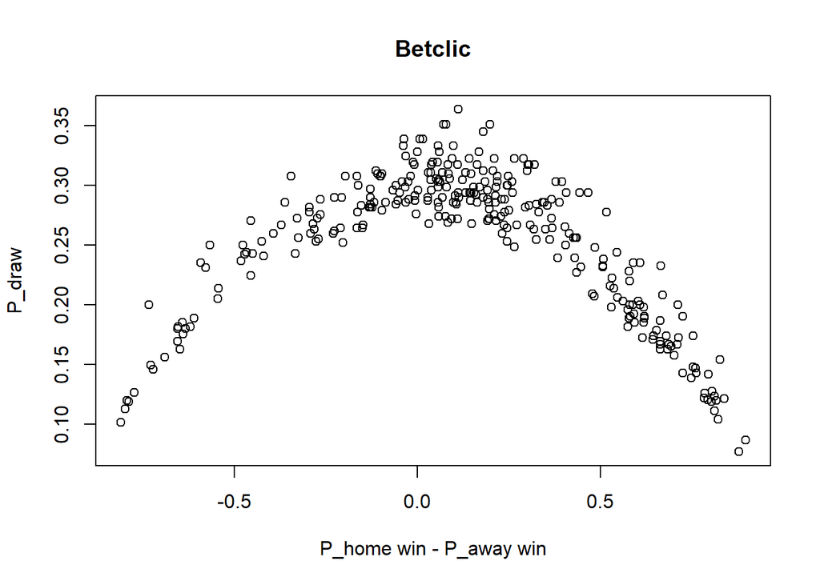

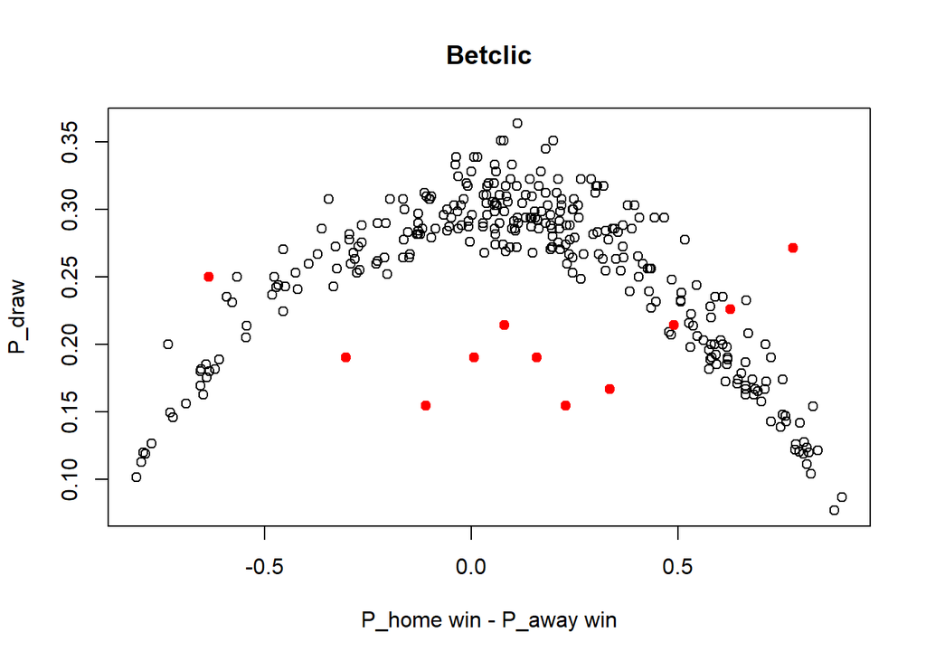

Since the red dots are not above the trends of the probabilities estimated by bookmaker, it is not profitable to bet in the long run except for 2 bins.

For second bookmaker(1xBet) the results are:

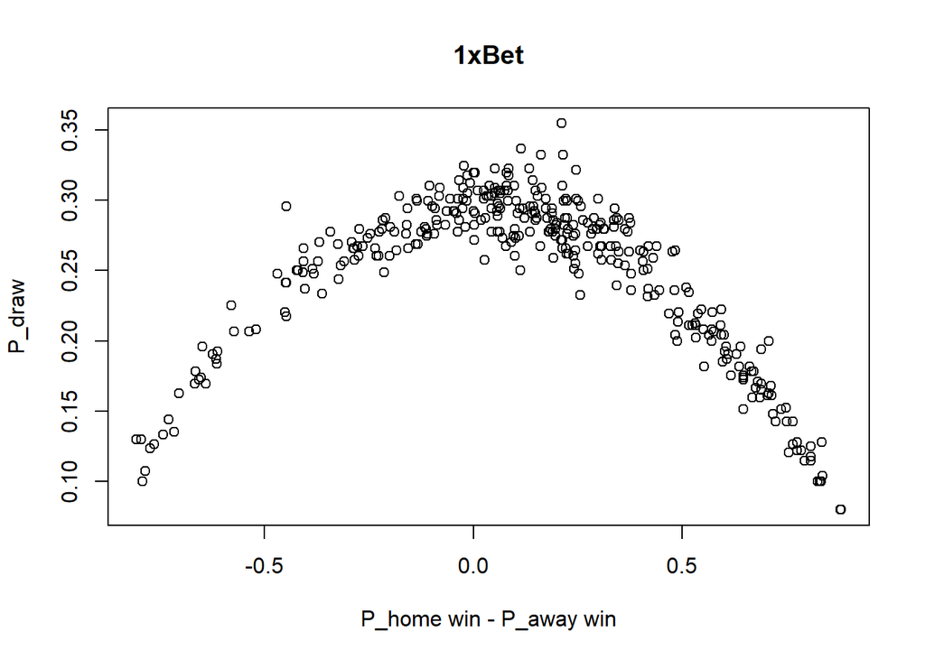

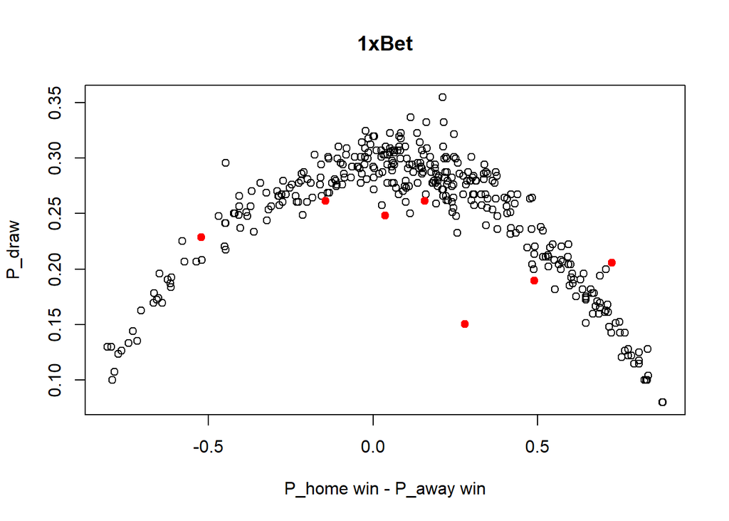

For third bookmaker(Betsafe) the results are:

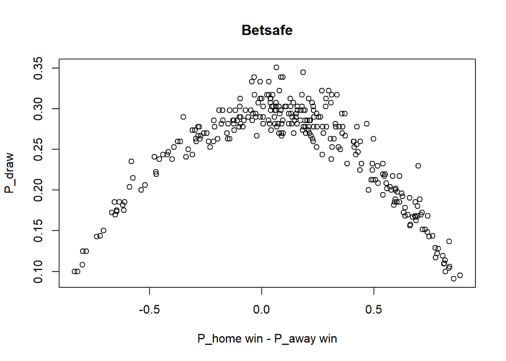

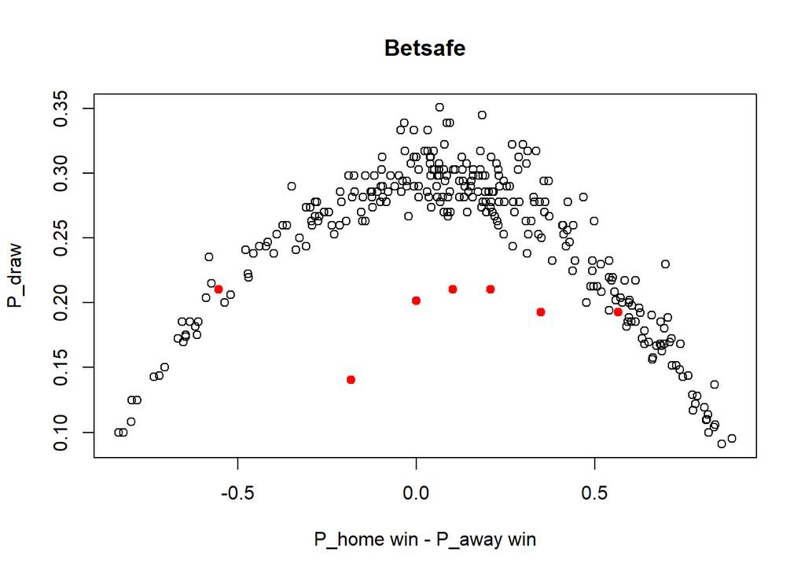

Since the red dots are not above the trends of the probabilities estimated by bookmaker, it is not profitable to bet in the long run.

For fourth bookmaker(5Dimes) the results are:

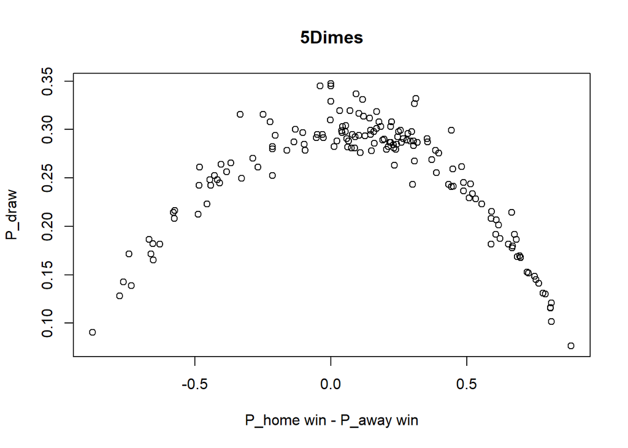

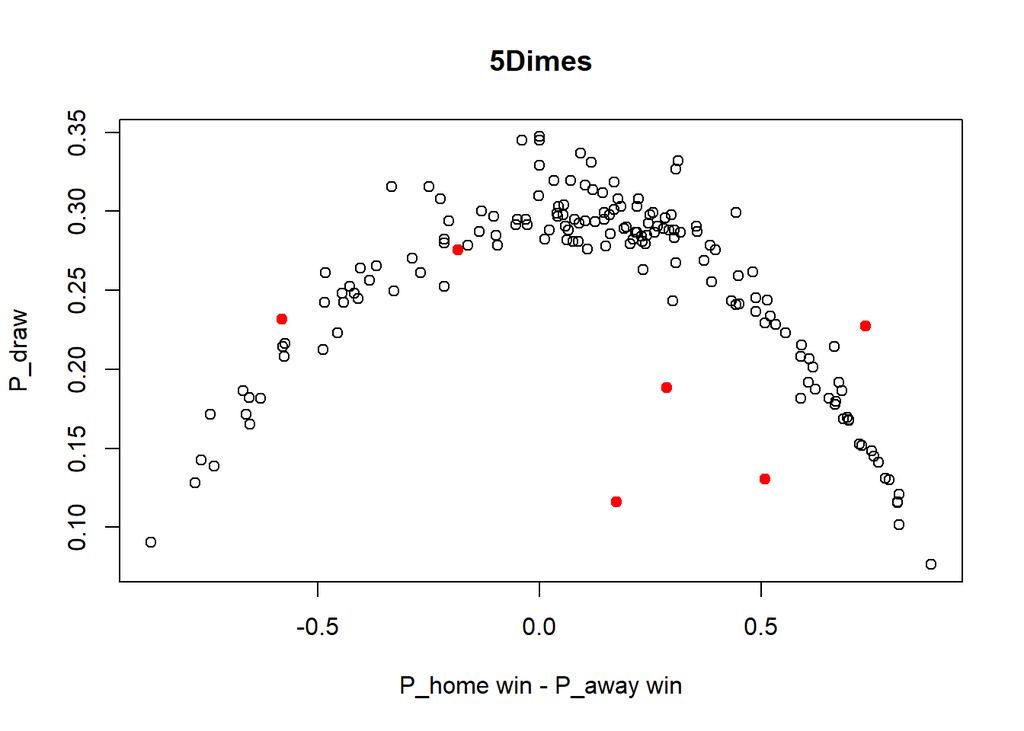

## TASK 3

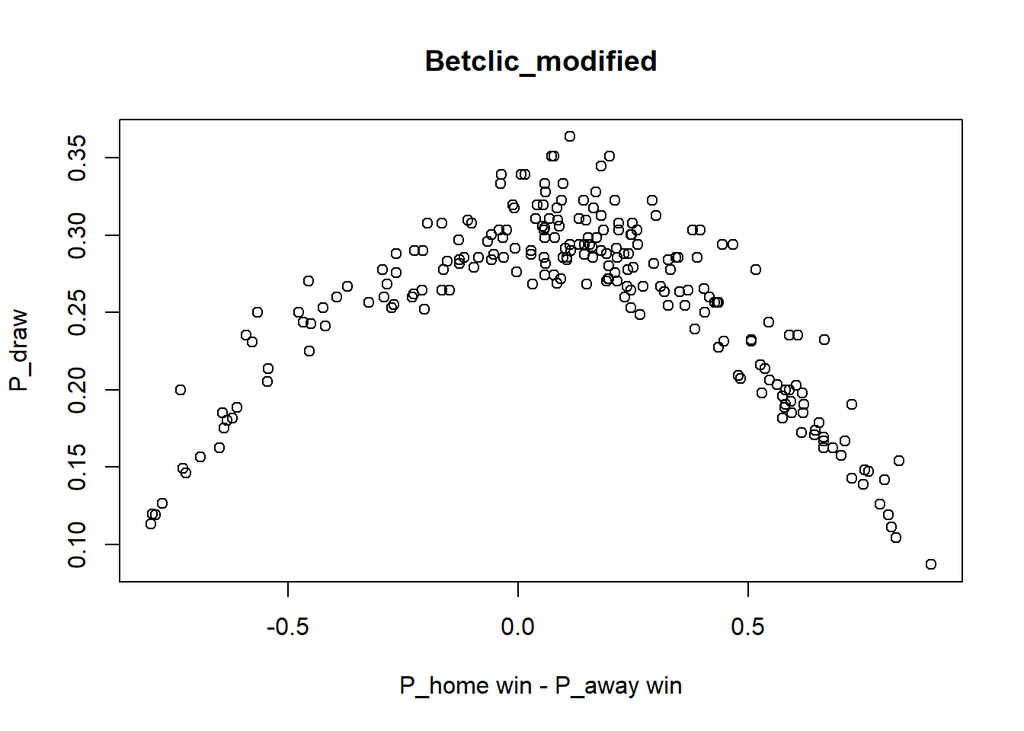

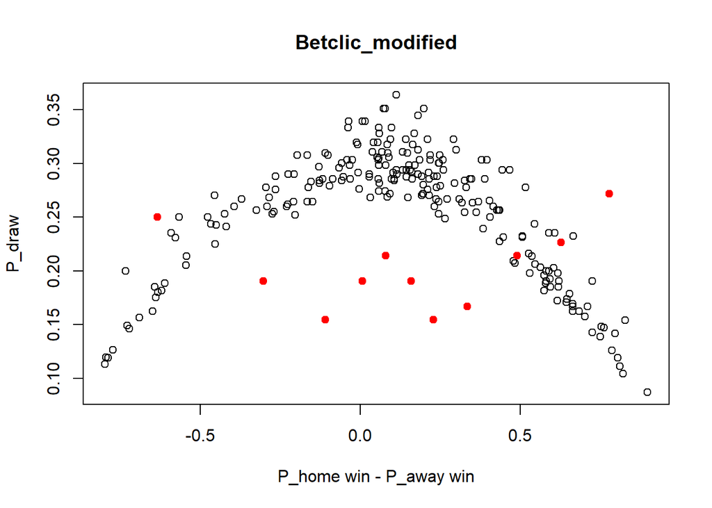

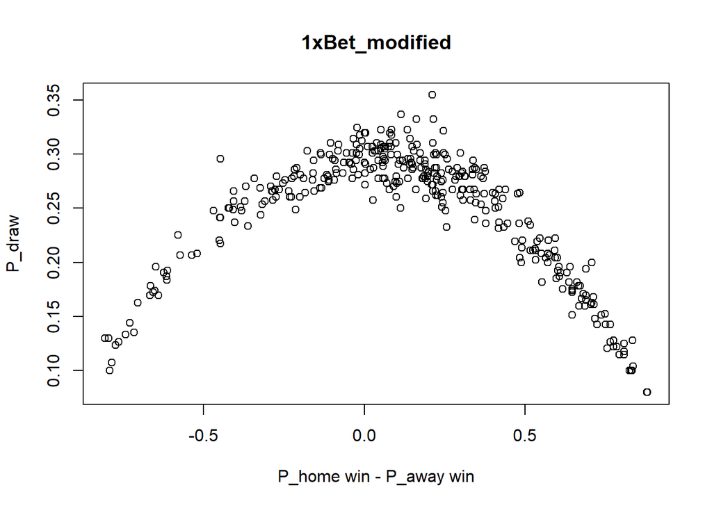

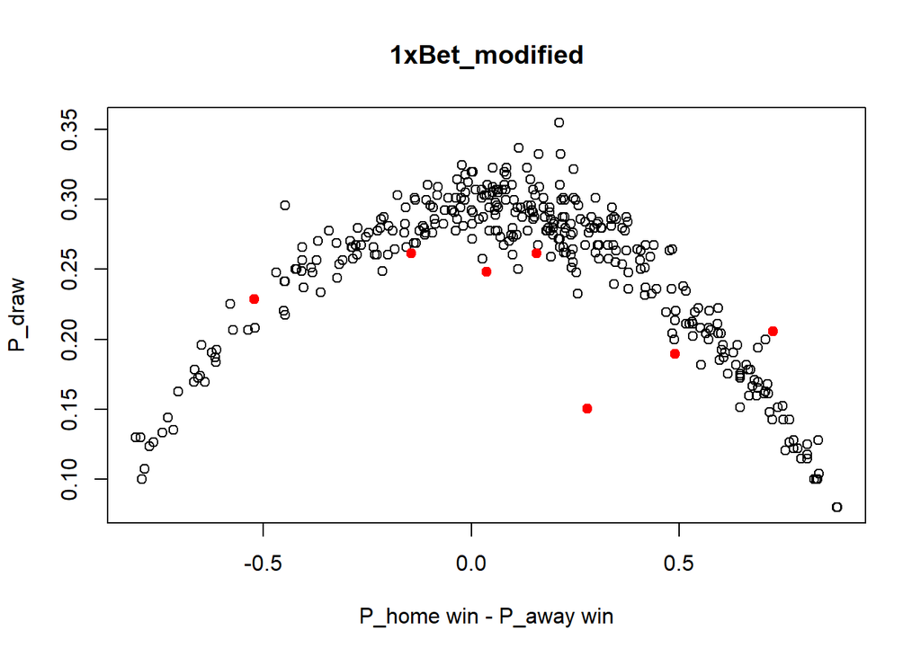

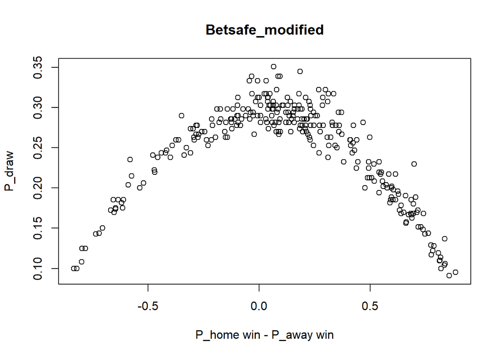

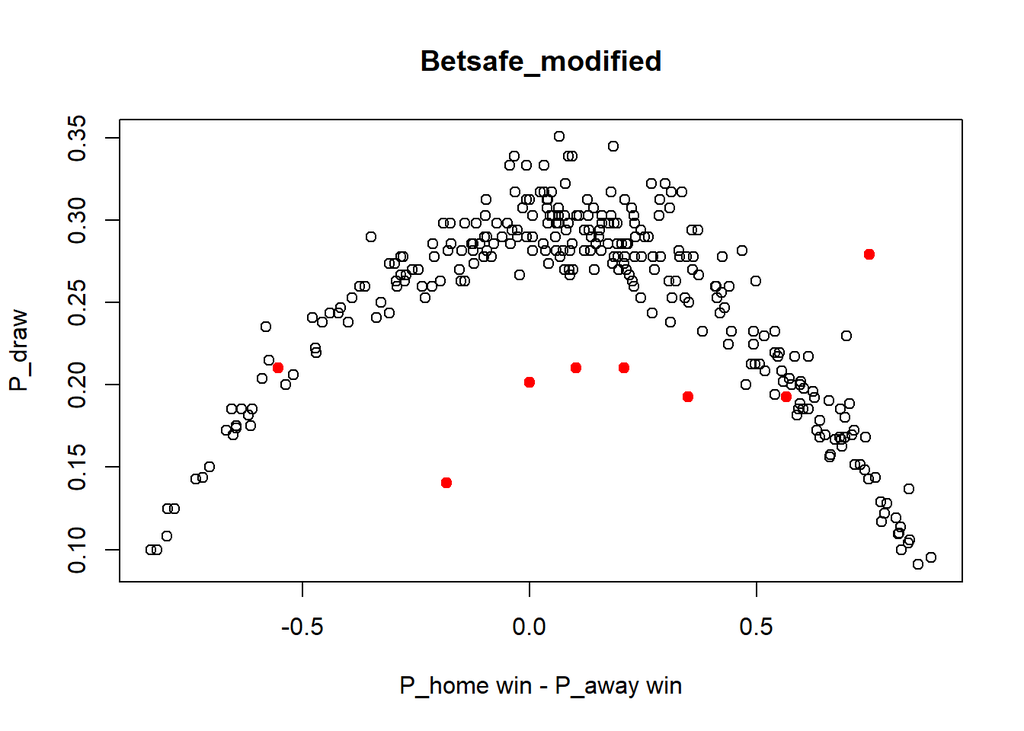

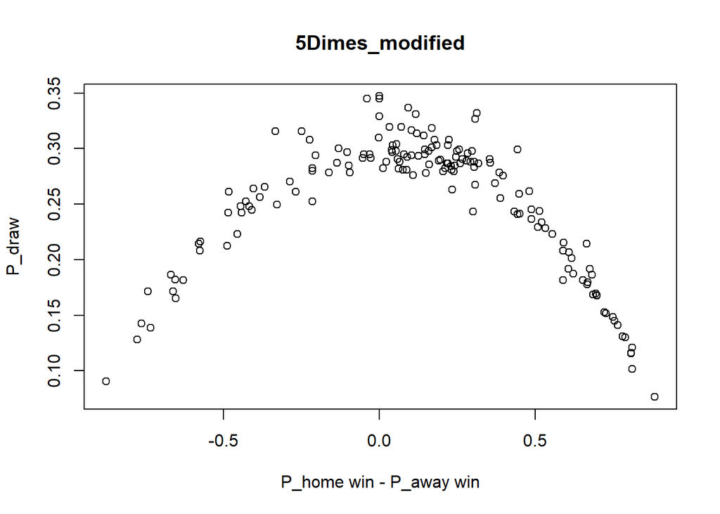

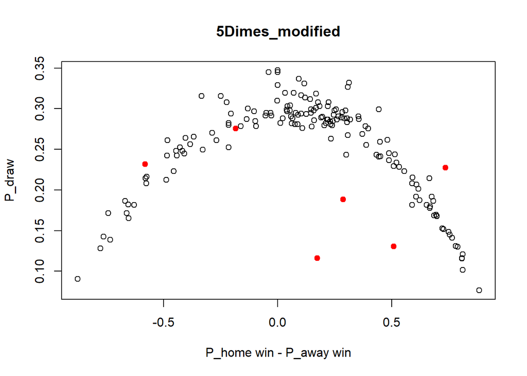